# Question 3

Can a company expect to have more financing rounds if they’re in a particular industry?

### Analysis

Import cleaned data and used libraries.

`r`r library(ggplot2) fundingData <- readRDS(_data_cleaned.rds)

### What do Funding Rounds look like?

`r`r summary(fundingData$funding_rounds)

```
   Min. 1st Qu.  Median    Mean 3rd Qu.    Max.
  1.000   1.000   2.000   2.166   3.000  18.000
```

`r`r print(c(, mean(fundingData$funding_rounds)))

```
[1] \Mean\             \2.16617351791187\
```

`r`r print(c(, var(fundingData$funding_rounds)))

```
[1] \Var\              \2.68049586716868\
```

`r`r hist(fundingData$funding_rounds, prob=TRUE) lines(1:max(fundingData$funding_rounds), dexp(0:(max(fundingData$funding_rounds)-1), 1/mean(fundingData$funding_rounds)), col = 'blue') r lines(1:max(fundingData$funding_rounds), dnbinom(0:(max(fundingData$funding_rounds)-1), 1, mu=1/mean(fundingData$funding_rounds)), col = 'red')

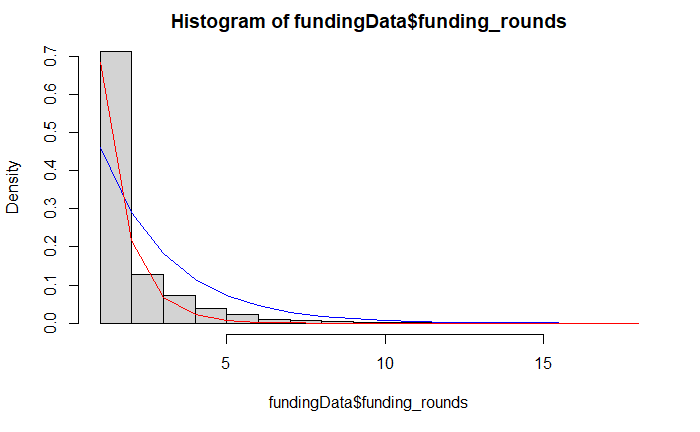

The average amount of funding, when we only include rounds that received funding, increases steadily throughout the rounds, starting at an average of $7 million in Round A and ending with an average $50 million in Round H. However, the most money raised in total is in Round B, due to the higher average than Round A combined with higher frequency than all later rounds.

`r`r roundFunding <- fundingData[fundingData[*total] > 0,grep(*.$, colnames(fundingData))] is.na(roundFunding) <- roundFunding==0 roundFunding.mean <- colMeans(roundFunding, na.rm=TRUE) roundFunding.sum <- colSums(roundFunding, na.rm=TRUE) print(roundFunding.mean)

```
 round_A  round_B  round_C  round_D  round_E  round_F  round_G  round_H
 7084554 14307771 21113539 29833659 32774401 47631313 49744194 50000000
```

Figure x1: The average amount of money raised in each round

`r`r barplot(roundFunding.mean)

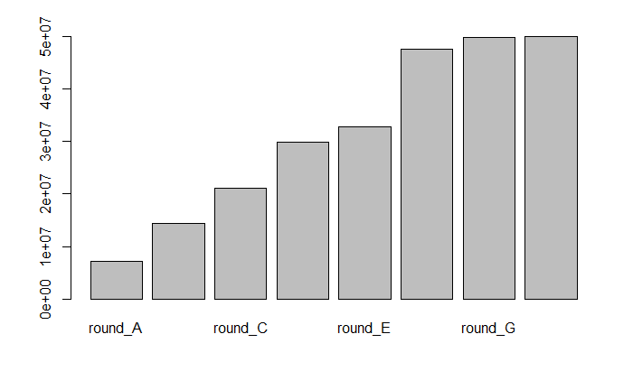

Figure x2: The expecation of how much money can be raised in a particular round

`r`r barplot(roundFunding.sum)

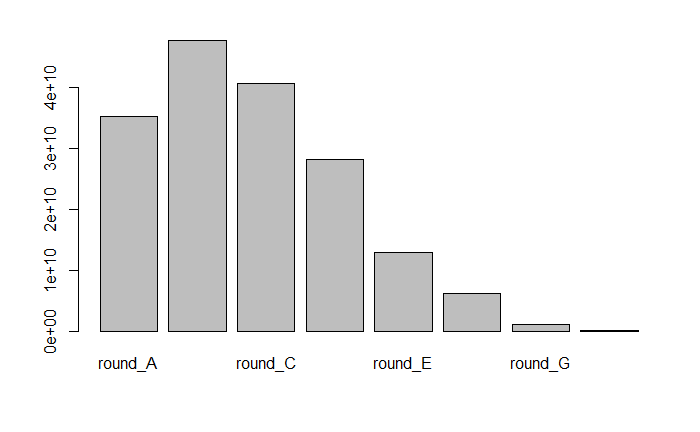

### How does it relate to market?

We restrict the analysis to markets with at least 30 companies recorded.

## ? Why are we using (funding_total_usd, venture, seed) instead of just funding_total_usd?

`r`r industryList <- c('Travel','Transportation','Games','Music','Video','Finance','Cloud Computing','Health Care','Hospitality','Education') targetMarketData <- subset(fundingData, market %in% industryList) industryData <- do.call(data.frame, aggregate(cbind(funding_rounds, funding_total_usd, venture, seed) ~ market, data=targetMarketData, FUN=function(x) c(mn = mean(x), var = var(x)))) industryData$n <- aggregate(funding_total_usd ~ market, data=targetMarketData, FUN=length)$funding_total_usd summary(industryData$funding_rounds.mn)

```
   Min. 1st Qu.  Median    Mean 3rd Qu.    Max.
  1.655   1.992   2.114   2.176   2.414   2.756
```

Variance does not seem to be consistent between industries.

`r`r #Variance in rounds is not equal summary(industryData$funding_rounds.var)

```
   Min. 1st Qu.  Median    Mean 3rd Qu.    Max.
  1.178   1.715   1.993   2.499   3.065   4.729
```

`r`r hist(industryData$funding_rounds.var)

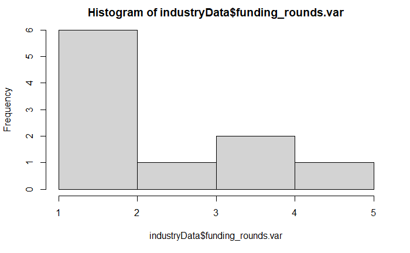

By market model

`r`r model <- lm(funding_total_usd.mn ~ funding_rounds.mn, data=industryData ) summary(model)

```
Call:
lm(formula = funding_total_usd.mn ~ funding_rounds.mn, data = industryData)

Residuals:
     Min       1Q   Median       3Q      Max
-9843541 -7352334 -3629244  3880320 28716906

Coefficients:
                   Estimate Std. Error t value Pr(>|t|)
(Intercept)       -46679792   27640221  -1.689   0.1297
funding_rounds.mn  30837059   12578447   2.452   0.0398 *
---
Signif. codes:  0 â€˜***â€™ 0.001 â€˜**â€™ 0.01 â€˜*â€™ 0.05 â€˜.â€™ 0.1 â€˜ â€™ 1

Residual standard error: 12220000 on 8 degrees of freedom
Multiple R-squared:  0.429, Adjusted R-squared:  0.3576
F-statistic:  6.01 on 1 and 8 DF,  p-value: 0.03984
```

`r`r plot(model)

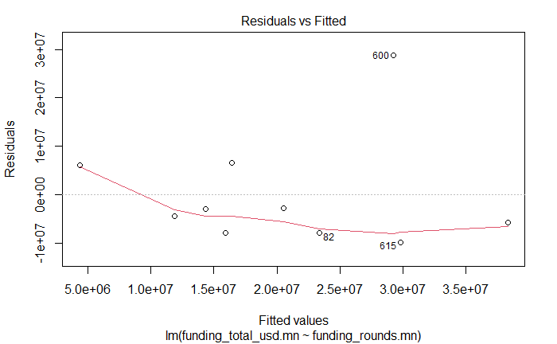

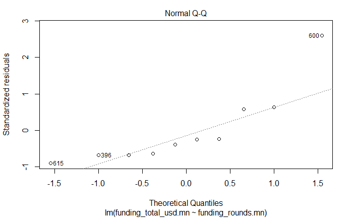

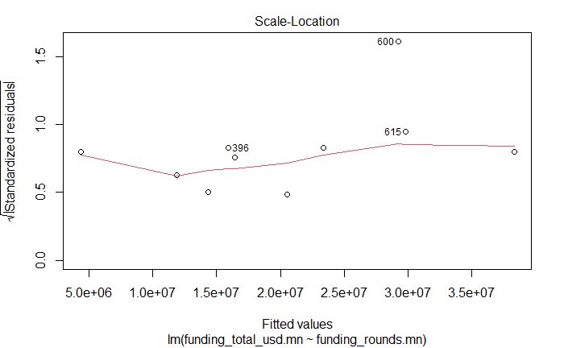

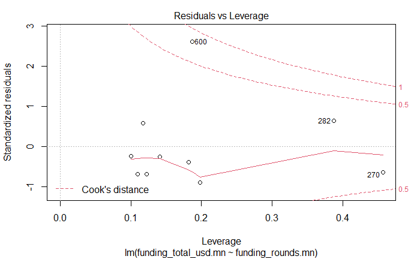

within market model

`r`r model <- lm(venture ~ funding_rounds + market, data=targetMarketData ) summary(model)

```
Call:
lm(formula = venture ~ funding_rounds + market, data = targetMarketData)

Residuals:
       Min         1Q     Median         3Q        Max
-104402400   -8887578   -2528269    3004970 1418707568

Coefficients:
                     Estimate Std. Error t value Pr(>|t|)
(Intercept)          -6526715    5402081  -1.208    0.227
funding_rounds        9054984     588531  15.386  < 2e-16 ***
marketEducation      -5533239    5790639  -0.956    0.339
marketFinance        -3520964    5785059  -0.609    0.543
marketGames          -2695674    5690363  -0.474    0.636
marketHealth Care     2813947    5524116   0.509    0.611
marketHospitality    -3007390    6405612  -0.469    0.639
marketMusic          -6309477    6811945  -0.926    0.354
marketTransportation 39489246    8750956   4.513 6.75e-06 ***
marketTravel          5664125    7069215   0.801    0.423
marketVideo           3235828    6854094   0.472    0.637
---
Signif. codes:  0 â€˜***â€™ 0.001 â€˜**â€™ 0.01 â€˜*â€™ 0.05 â€˜.â€™ 0.1 â€˜ â€™ 1

Residual standard error: 43790000 on 2173 degrees of freedom
Multiple R-squared:  0.1287,    Adjusted R-squared:  0.1247
F-statistic:  32.1 on 10 and 2173 DF,  p-value: < 2.2e-16
```

`r`r plot(model)

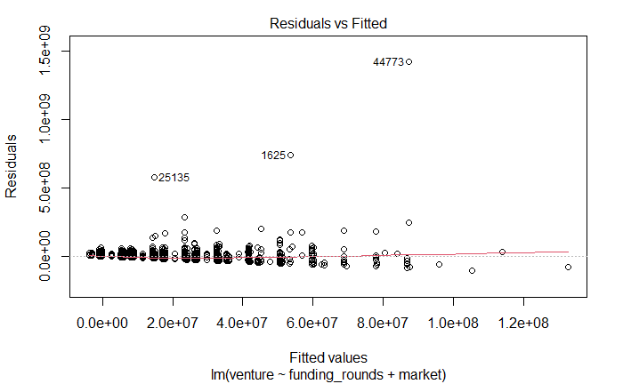

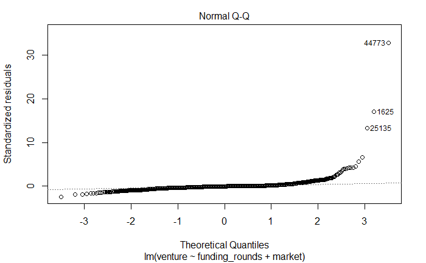

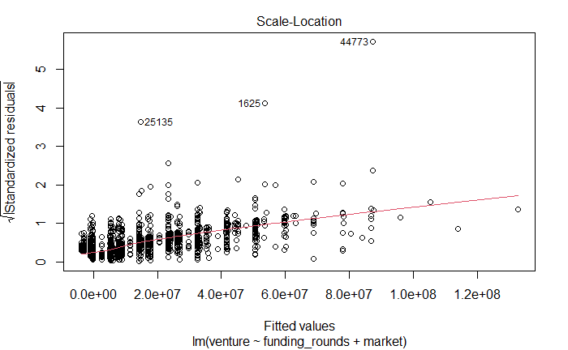

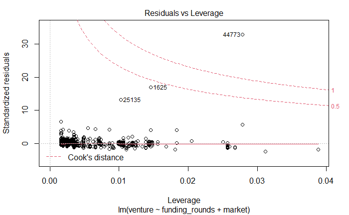